# ML-tutorial

### חלוקה לקטגוריות

בגדול יש שתי סוגי משתנים:

- משתנים רציפים
- משתנים קטגוריאלים

יש כל מיני סיבות למה נרצה לאגד משתנים לקטגוריות:

- חיסון מפני ערכים קיצוניים
- יותר מתאים לרגרסיה לוגיסטית
- יצירת קבוצות הומוגניות מבחינת משתנה המטרה
- ועוד

#### משתנים רציפים

יש מספר דרכים לחלק משתנים רציפים לקבוצות משמעותיות ביחס למשתנה מטרה

אנחנו נציג שיטה גרפית פשוטה:

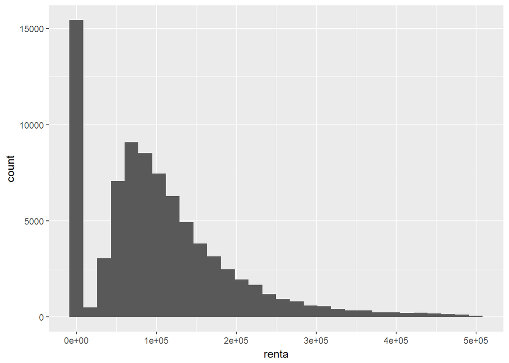

```r
model_data %>%
  filter(renta<500000) %>%
  ggplot(.,aes(x=renta)) +
  geom_histogram()
```

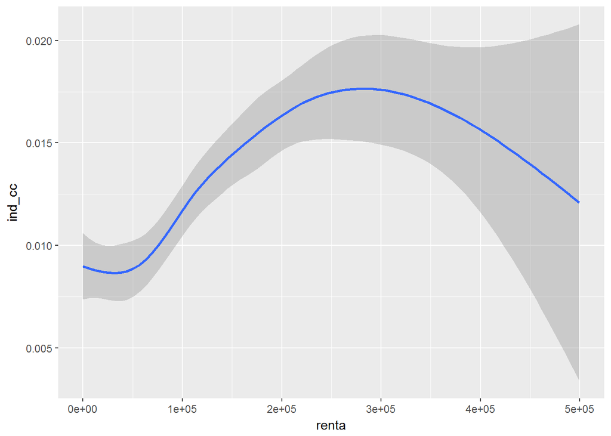

```r
model_data %>%
  filter(renta<500000) %>%
  ggplot(.,aes(x=renta, y= ind_cc)) +
  geom_smooth()
```

משני הגרפים לעיל רואים גם:

- בעזרת ההיסטוגרמה נדאג שהקבוצות לא יהיו קטנות מדי
- בעזרת ה loess נחתוך לקבוצות עם ממוצע משתנה מטרה דומה
- יש גרעין גדול ב 0
- בקושי יש ערכים מעל 300,000

בדוגמא הייתי בוחר לחתוך בערך ב - 50,000 100,000 ו 300,000

אפשר לחתוך בעזרת `cut` אבל מהתרגיל יש לכם כבר כלי חזק לחתוך משתנים לקטגוריות.

```r
########################################################
# First lets make a format function maker
# Answer to question 6 format function:

grp_fmt<- function(...){
            function(data_var){
              data_var <-  cut(data_var
                               , include.lowest=TRUE
                               , right=TRUE
                               , dig.lab = 7
                               ,breaks=c(min(data_var), ... , max(data_var)))
              data_var
                                }
            }
```

יצרנו מעטפת לפקודת cut , המאפשרת חיתוך מהיר ושמירת התיעוד של החיתוך בתצורה של פונקציה

הפונקציה מחזירה פונקציה הדומה לפורמט של SAS

ניתן להשתמש בה כמעט בכל מקום…

**אבל יש לה מקום לשיפור… איך הייתם מתקנים אותה כדי שתטפל בערכים חסרים?**

```r
##############################################
# What if Im not sure where to cut?
# I can create 2 options

fmt_renta1 <- grp_fmt(50000, 150000,250000)
fmt_renta2 <- grp_fmt(50000, 100000,300000)

##############################################
# And check them one by one like this:

model_train %>%
group_by(fmt_renta1(renta)) %>%
summarise(pct = mean(ind_cc, na.rm = T), Freq = n()) %>%
ungroup() %>%
mutate(grp_pct=Freq*100/sum(Freq))
```

```
## # A tibble: 4 × 4
##     `fmt_renta1(renta)`         pct  Freq   grp_pct
##                  <fctr>       <dbl> <int>     <dbl>
## 1             [0,50000] 0.008731587 15003 25.923110
## 2        (50000,150000] 0.011127419 29297 50.621166
## 3       (150000,250000] 0.016142919  9292 16.055292
## 4 (250000,2.203474e+07] 0.018911978  4283  7.400432
```

```r
##############################################
# I can store them in a list for future use:

fmtl_renta <- list( "fmt_renta1" = fmt_renta1
                   ,"fmt_renta2" = fmt_renta2)

names(fmtl_renta)
```

```
## [1] "fmt_renta1" "fmt_renta2"
```

```r
##############################################
# Or see them all at once with map or lapply:
map_df(fmtl_renta,
         ~ model_train %>%
          group_by(.(renta)) %>%
          summarise(pct = mean(ind_cc, na.rm = T),Freq = n()) %>%
          ungroup() %>%
          mutate(grp_pct=Freq*100/sum(Freq))
         )
```

```
## # A tibble: 8 × 4
##              `.(renta)`         pct  Freq   grp_pct
##                   <chr>       <dbl> <int>     <dbl>
## 1             [0,50000] 0.008731587 15003 25.923110
## 2        (50000,150000] 0.011127419 29297 50.621166
## 3       (150000,250000] 0.016142919  9292 16.055292
## 4 (250000,2.203474e+07] 0.018911978  4283  7.400432
## 5             [0,50000] 0.008731587 15003 25.923110
## 6        (50000,100000] 0.009227019 17232 29.774514
## 7       (100000,300000] 0.014888337 22971 39.690713
## 8 (300000,2.203474e+07] 0.020981641  2669  4.611663
```

*הדוגמה לעיל ממחישה את הגמישות המובנית בכתיבה פונקציונאלית*

#### משתנים קטגוריאלים

בשביל לבחון משתנה קטגוריאלי מספיק להסתכל על הממוצעים של אחוזי המשתנה הבינומי ביחס למספר התצפיות בכל קטגוריה

לרוב לא נרצה קבוצות קטנות מדי

לדוגמא במשתנה הבא רואים שיש קבוצה אחת קטנה מדי שכדאי לאחד עם אחד הקבוצות הגדולות

```r
model_train %>%
group_by(tiprel_1mes) %>%
summarise(pct = mean(ind_cc, na.rm = T)
          ,Freq = n()) %>%
ungroup() %>%
mutate(grp_pct=Freq*100/sum(Freq))
```

```
## # A tibble: 3 × 4
##   tiprel_1mes          pct  Freq      grp_pct
##         <chr>        <dbl> <int>        <dbl>
## 1           A 0.0133038125 51489 88.965874730
## 2           I 0.0004699248  6384 11.030669546
## 3           P 0.0000000000     2  0.003455724
```

נציג שתי אופציות לחתוך את המשתנה:

- בעזרת gui -> Addins -> Variable Cutting
- בעזרת הפקודה `recode`

```r
##########################################################################
# Option 1: Recode
#  I made this code with the GUI:

model_train$tiprel_1mes_rec <- model_train$tiprel_1mes
model_train$tiprel_1mes_rec[model_train$tiprel_1mes == "P"] <- "A"
model_train$tiprel_1mes_rec[model_train$tiprel_1mes == ""] <- "A"

# This turns it form a char vector to a factor:
model_train$tiprel_1mes_rec <- factor(model_train$tiprel_1mes_rec)

# Lets see the results
model_train %>%
group_by(tiprel_1mes_rec) %>%
summarise(pct = mean(ind_cc, na.rm = T) ,Freq = n()) %>%
ungroup() %>%
mutate(grp_pct=Freq*100/sum(Freq))
```

```
## # A tibble: 2 × 4
##   tiprel_1mes_rec          pct  Freq  grp_pct
##            <fctr>        <dbl> <int>    <dbl>
## 1               A 0.0133032957 51491 88.96933
## 2               I 0.0004699248  6384 11.03067
```

```r
##########################################################################
# Option 2: Recode
# There is a dplyr function for this called `recode` and
#  `recode_factor` (that turns it into an ordered factor), look at the help:

model_train %>%
group_by(recode_factor(tiprel_1mes,P="A")) %>%
summarise(pct = mean(ind_cc, na.rm = T) ,Freq = n()) %>%
ungroup() %>%
mutate(grp_pct=Freq*100/sum(Freq))
```

```
## # A tibble: 2 × 4
##   `recode_factor(tiprel_1mes, P = "A")`          pct  Freq  grp_pct
##                                  <fctr>        <dbl> <int>    <dbl>
## 1                                     A 0.0133032957 51491 88.96933
## 2                                     I 0.0004699248  6384 11.03067
```

כפי שאתם רואים שימוש ב GUI זה נחמד אבל דורש יצירת משתנה חדש וכתיבת הרבה קוד….

## מדדים לטיב המודל

- מודלים של רגרסיה לינאירת נסתכל ב R בריבוע
- לגבי מובהקות משתנים נשתמש ב `drop1` העושה מבחן `TYPE III` בדומה ל SAS
- ברגרסיה בינומית אפשר להסתכל על מה שהכי מקטין את ה `deviance`
- את המדדים למודלים בינארים נקח מחבילת ROCR או pROC.

**נראה אותם בהמשך**

# אקונומטריקה קלאסית

## Syntax של משוואה

כאן נעבור על ה syntax שילווה אותנו ברוב הפקודות של רגרסיות ועוד.

רגרסיות ב R מוגדרות על ידי `formula` מהסוג:

> y ~ x1 + X2

כאשר `+` פירושו עוד משתנה ולא חיבור מתמטי

### טרנספורמציה בתוך נוסחא

ניתן לבצע כל טרנספורמציה בתוך שורת הנוסחא

> y ~ exp(x1) + factor(X2)
- כמובן שאפשר גם להשתמש בפונקציה `grp_frmt` שיצרנו גם בתוך שורת הרגרסיה!*

### פעולה מתמטית בתוך נוסחא

אם רוצים פעולה מתמטית יש לכתוב זאת בתוך `I`

> y ~ I(x1^2) + I(X2*x1)

### אינטראקציה בין משתנים

אינטראקציה בין משתנים נסמן בסימן `*` כאשר אנטראקציה עם המשתנה עצמו נסמן בהעלאה בחזקה `^`

> y ~ x1^2 + X2*x1

### פולינום על משתנה

במקום להוסיף ידנית את ערכי הפולינום אפשר לסמן פולינום על משתנה בעזרת הפקודה `poly`

> y ~ x1 + poly(X2,4)

אבל יתכן ותרצו במקרה כזה להשתמש ב spline , יש פונקציה בחבילת `splines`, הפונקציה `ns()`

### רגרסיה בלי חותך

רגרסיה בלי חותך נסמן על ידי חיסור של 1

> y ~ x1 -1

עכשיו שאתם יודעים איך לכתוב נוסחא, נריץ כמה מודלים

## פקודות נפוצות למודלים

כמעט לכל השיטות המחזירות מודלים יש את הפקודות הבאות, כאשר לכל שיטה יש את הנואנסים שלה:

- `summary` - מציג סיכום תוצאות המודל
- `predict` - מייצר ערכים חזויים
- `coefficients` - מחזיר את המקדמים
- `resid` - מחזיר את השאריות
- `drop1` - מבחן F למובהקות המשתנה - SAS TYPE III
- מי שרוצה לשדרג את העבודה עם רגרסיות - שיסתכל בחבילת `broom`*

## רגרסיה ליניארית

בוא נריץ רגרסיה ליניארית על renta

ה syntax הבסיסי:

> lm(formula, data)

```r
options(
  contrasts = c("contr.treatment", "contr.treatment"),
  na.option = na.exclude
    )


reg_lm1 <- lm(renta ~ segmento + poly(age,3), data = model_train)


# regression outcomes
summary(reg_lm1)
```

```
##
## Call:
## lm(formula = renta ~ segmento + poly(age, 3), data = model_train)
##
## Residuals:
##      Min       1Q   Median       3Q      Max
##  -174519   -65324   -20361    32033 21929374
##
## Coefficients:
##                            Estimate Std. Error t value Pr(>|t|)
## (Intercept)                  143935       3222  44.667  < 2e-16 ***
## segmento02 - PARTICULARES    -30553       3281  -9.312  < 2e-16 ***
## segmento03 - UNIVERSITARIO   -42334       4336  -9.763  < 2e-16 ***
## poly(age, 3)1               2439184     286018   8.528  < 2e-16 ***
## poly(age, 3)2                853683     233438   3.657 0.000255 ***
## poly(age, 3)3              -1491289     206721  -7.214  5.5e-13 ***
## ---
## Signif. codes:  0 '***' 0.001 '**' 0.01 '*' 0.05 '.' 0.1 ' ' 1
##
## Residual standard error: 205700 on 57869 degrees of freedom
## Multiple R-squared:  0.008568,   Adjusted R-squared:  0.008483
## F-statistic:   100 on 5 and 57869 DF,  p-value: < 2.2e-16
```

```r
# Type III paramter test
drop1(reg_lm1, test = "F")
```

```
## Single term deletions
##
## Model:
## renta ~ segmento + poly(age, 3)
##              Df  Sum of Sq        RSS     AIC F value    Pr(>F)
## <none>                     2.4480e+15 1416098
## segmento      2 4.4141e+12 2.4524e+15 1416198  52.173 < 2.2e-16 ***
## poly(age, 3)  3 6.9634e+12 2.4550e+15 1416256  54.870 < 2.2e-16 ***
## ---
## Signif. codes:  0 '***' 0.001 '**' 0.01 '*' 0.05 '.' 0.1 ' ' 1
```

```r
# coefficients
coefficients(reg_lm1)
```

```
##                (Intercept)  segmento02 - PARTICULARES
##                  143935.00                  -30553.09
## segmento03 - UNIVERSITARIO              poly(age, 3)1
##                  -42333.61                 2439184.11
##              poly(age, 3)2              poly(age, 3)3
##                  853683.43                -1491289.32
```

```r
# residuals and predictons
resid(reg_lm1) %>% str()
```

```
##  Named num [1:57875] 286275 -59210 14639 -21036 -46092 ...
##  - attr(*, "names")= chr [1:57875] "1" "2" "3" "4" ...
```

```r
predict(reg_lm1, model_train) %>% str()
```

```
##  Named num [1:57875] 127841 158394 108642 109731 118429 ...
##  - attr(*, "names")= chr [1:57875] "1" "2" "3" "4" ...
```

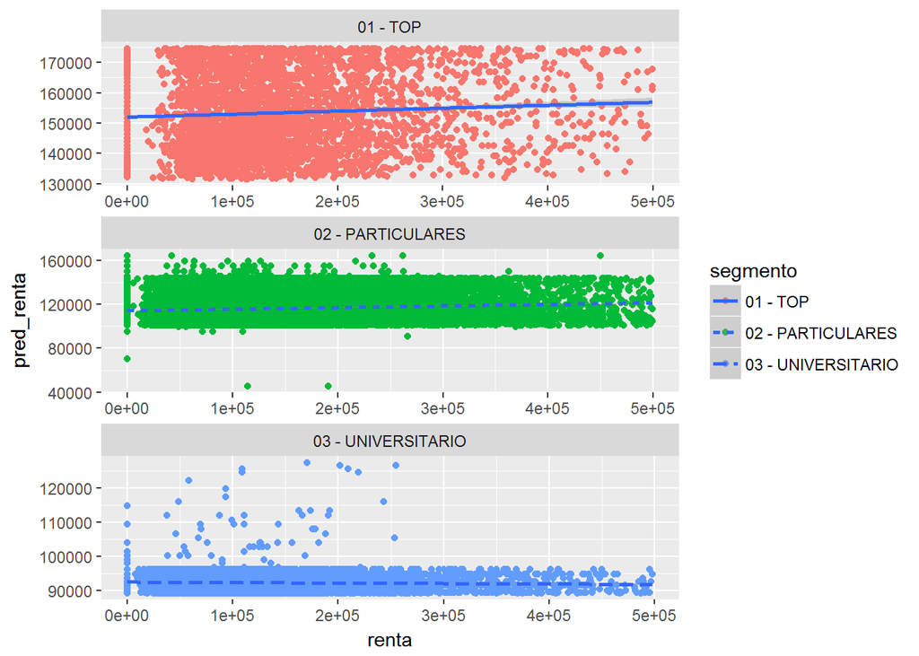

```r
# predict values and residuals
reg_ml1_data <- model_train %>%
                mutate( pred_renta = predict(reg_lm1, model_train)
                       ,resid_renta = resid(reg_lm1)) %>%
                select(renta, pred_renta, resid_renta, segmento, age)


######################################
# Lets examine some graphs...

reg_ml1_data %>%
  filter(renta < 500000) %>%
ggplot(.,aes(renta, pred_renta)) +
  geom_point(aes(color=segmento)) +
  geom_smooth(aes(linetype = segmento), method = "lm") +
  facet_wrap(~segmento, scales = "free", ncol = 1)
```

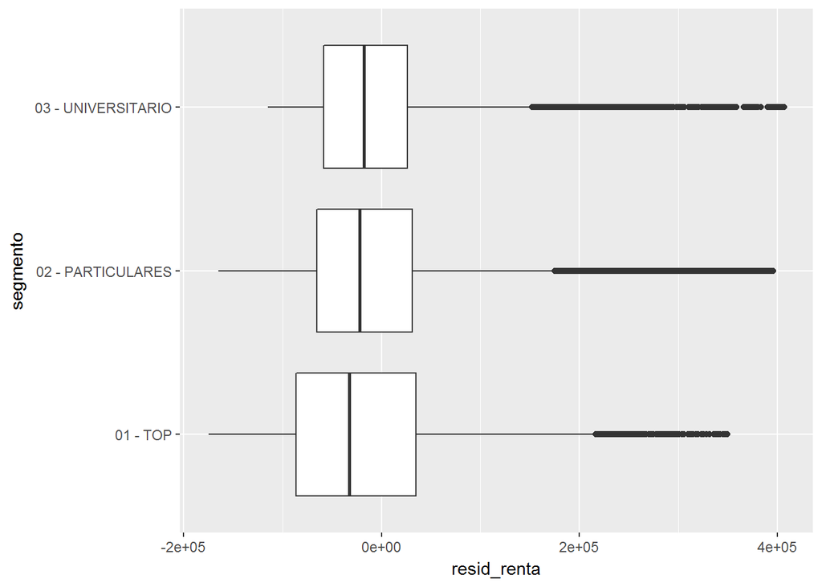

```r
# Well, that looks pretty bad!
#   Let see the residuals:

# With respect to segmento:
reg_ml1_data %>%
  filter(renta < 500000) %>%
    ggplot(.,aes(segmento, resid_renta)) +
    geom_boxplot() +
    coord_flip()
```

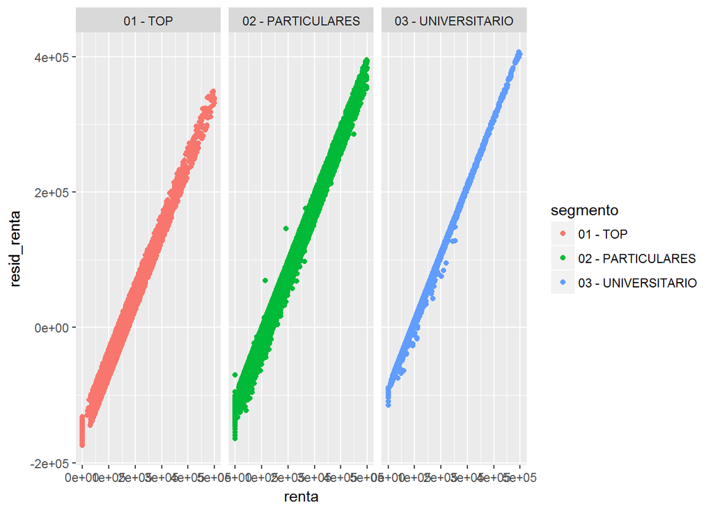

```r
# With respect to renta:
reg_ml1_data %>%
  filter(renta < 500000) %>%
    ggplot(.,aes(renta, resid_renta)) +
    geom_jitter(aes(color = segmento)) +
    facet_wrap(~segmento)
```

טוב, זה היה דוגמא לרגרסיה גרועה! :)

אבל הבנתם את העקרון…

- לגבי מדדי החלטה ה R2 שלנו כ 0.008

## רגרסיה לוגיסטית

רגרסיה לוגיסטית שייכת למשפחת הרגרסיות של glm

ה syntax הבסיסי לרגרסיה לוגיסטית היא:

> glm(formula, data, family=binomial(link = “logit”))

```r
reg_log1 <- glm(ind_cc~ segmento + sexo
                ,model_train
                ,family=binomial(link = "logit"))

drop1(reg_log1, test = "LRT")
```

```
## Single term deletions
##
## Model:
## ind_cc ~ segmento + sexo
##          Df Deviance    AIC     LRT Pr(>Chi)
## <none>        7222.3 7230.3
## segmento  2   7455.1 7459.1 232.763  < 2e-16 ***
## sexo      1   7225.7 7231.7   3.363  0.06667 .
## ---
## Signif. codes:  0 '***' 0.001 '**' 0.01 '*' 0.05 '.' 0.1 ' ' 1
```

```r
summary(reg_log1)
```

```
##
## Call:
## glm(formula = ind_cc ~ segmento + sexo, family = binomial(link = "logit"),
##     data = model_train)
##
## Deviance Residuals:
##     Min       1Q   Median       3Q      Max
## -0.2563  -0.1671  -0.1555  -0.0820   3.4182
##
## Coefficients:
##                            Estimate Std. Error z value Pr(>|z|)
## (Intercept)                -3.54435    0.10030 -35.338   <2e-16 ***
## segmento02 - PARTICULARES  -0.86549    0.09693  -8.929   <2e-16 ***
## segmento03 - UNIVERSITARIO -2.29468    0.16991 -13.505   <2e-16 ***
## sexoV                       0.14516    0.07959   1.824   0.0682 .
## ---
## Signif. codes:  0 '***' 0.001 '**' 0.01 '*' 0.05 '.' 0.1 ' ' 1
##
## (Dispersion parameter for binomial family taken to be 1)
##
##     Null deviance: 7466.6  on 57874  degrees of freedom
## Residual deviance: 7222.3  on 57871  degrees of freedom
## AIC: 7230.3
##
## Number of Fisher Scoring iterations: 8
```

```r
# coefficients
head(coefficients(reg_log1))
```

```
##                (Intercept)  segmento02 - PARTICULARES
##                 -3.5443458                 -0.8654904
## segmento03 - UNIVERSITARIO                      sexoV
##                 -2.2946789                  0.1451639
```

```r
# residuals
head(resid(reg_log1))
```

```
##          1          2          3          4          6          7
## -0.1670844 -0.2563392 -0.1670844 -0.1554597 -0.1554597 -0.1670844
```

```r
# predict values

pred_vals <- predict(reg_log1, model_train,  type = "response")
head(pred_vals)
```

```
##          1          2          3          4          6          7
## 0.01386163 0.03232104 0.01386163 0.01201115 0.01201115 0.01386163
```

שימו לב שב `predict` השתמשתי ב `response`

מה הייתי מקבל אם לא הייתי מציין את זה?

בשביל מדד לטיב הניבוי נסתכל על מדד gini שנגזר מחישוב AUC - את החישוב נעשה בעזרת ספריית `pROC`

הפקודה `auc` לוקחת ערך בפועל וערך חזוי

```r
library(pROC)
###### In Sample

# AUC from ROC
auc(model_train$ind_cc, pred_vals)
```

```
## Area under the curve: 0.6429
```

```r
# Gini coefficient
auc(model_train$ind_cc, pred_vals)*2-1
```

```
## [1] 0.2857619
```

```r
###### Out of Sample
pred_vals <- predict(reg_log1, model_test,  type = "response")
# AUC from ROC
auc(model_test$ind_cc, pred_vals)
```

```
## Area under the curve: 0.6573
```

```r
# Gini coefficient
auc(model_test$ind_cc, pred_vals)*2-1
```

```
## [1] 0.3145218
```

חבילת pROC מאפשר עוד כל מיני גרפים , חפשו בעזרה לעוד אפשרויות

- יש גם גרפים גנריים לכל רגרסיה - אבל זה בעיקר scatterplot שלוקחים הרבה זמן להדפיס….

עוד שימוש שאפשר לעשות עם כתיבה פונקציונאלית זה לבדוק מספר רגרסיות בשורה אחת:

```r
fmrla_list <- list(
                    frml1 = ind_cc~ segmento + sexo
                    ,frml2 = ind_cc~ segmento + sexo + renta
                  )


fmrla_list %>%
map(. ,function(x) glm(x
                      ,model_train
                      ,family=binomial(link = "logit"))
     )
```

```
## $frml1
##
## Call:  glm(formula = x, family = binomial(link = "logit"), data = model_train)
##
## Coefficients:
##                (Intercept)   segmento02 - PARTICULARES
##                    -3.5443                     -0.8655
## segmento03 - UNIVERSITARIO                       sexoV
##                    -2.2947                      0.1452
##
## Degrees of Freedom: 57874 Total (i.e. Null);  57871 Residual
## Null Deviance:       7467
## Residual Deviance: 7222  AIC: 7230
##
## $frml2
##
## Call:  glm(formula = x, family = binomial(link = "logit"), data = model_train)
##
## Coefficients:
##                (Intercept)   segmento02 - PARTICULARES
##                 -3.564e+00                  -8.604e-01
## segmento03 - UNIVERSITARIO                       sexoV
##                 -2.286e+00                   1.458e-01
##                      renta
##                  1.208e-07
##
## Degrees of Freedom: 57874 Total (i.e. Null);  57870 Residual
## Null Deviance:       7467
## Residual Deviance: 7221  AIC: 7231
```

# שיטות ב Machine Learning

בחלק הזה אנחנו נסקור בקצרה 3 שיטות מובילות ב ML:

- Clustering
- Decision Trees
- PCA

את כל השיטות ניתן לעשות במגוון חבילות ובראשן CARET , שם יש פקודה אחת `train` שלוקחת כפרמטר את השיטה לחישוב

אנחנו ננסה להדגים עם כמה ספריות בשביל להרחיב קצת את האופקים….

## מציאת אשכולות - Clustering

אפשר לחשב cluster ב R בעזרת ספריית `cluster` הבא מובנה עם התוכנה

על מנת לבדוק את מספר האשכולות נחשב את סכום השונות בתוך האשכולות לכמה

מספרי אשכולות ונבחר בהתאם

נשתמש בנתונים שכבר מרכזנו בפרק של טרנספורמציות…

הסינטקס הבסיסי:

> kmeans(data,centers)

```r
library(cluster)

###############################
# This is the basic function:

o_kmean<- kmeans(model_data_centered, centers=7)

############## Choose K through `Elbow` method #######

# Make a function that takes number of centers
# and returns the sum of within errors

c_func<-function(k){sum(kmeans(model_data_centered,centers=k)$withinss)}
c_func(8)
```

```
## [1] 31123.61
```

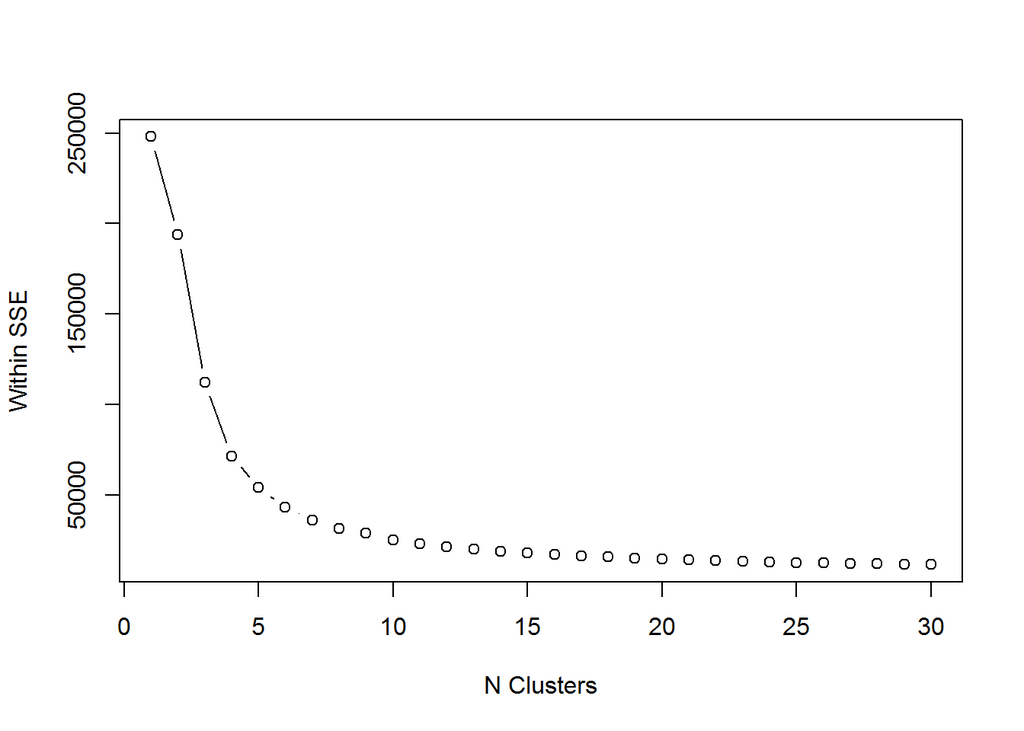

```r
## Lets feed our function to `map_dbl`
# Iterate over h = numbers 1 to 30
h <- seq(1,30)
wss <- map_dbl(h,c_func)
# plot the results
plot(h,wss,type="b",xlab="N Clusters", ylab="Within SSE")
```

```r
######### Choose a cluster
# Based on the graph lets take k=7

o_kmean<- kmeans(model_data_centered, centers=7)
table(o_kmean$cluster)
```

```
##
##     1     2     3     4     5     6     7
## 18428    18  2461   978  7419 27717 25657
```

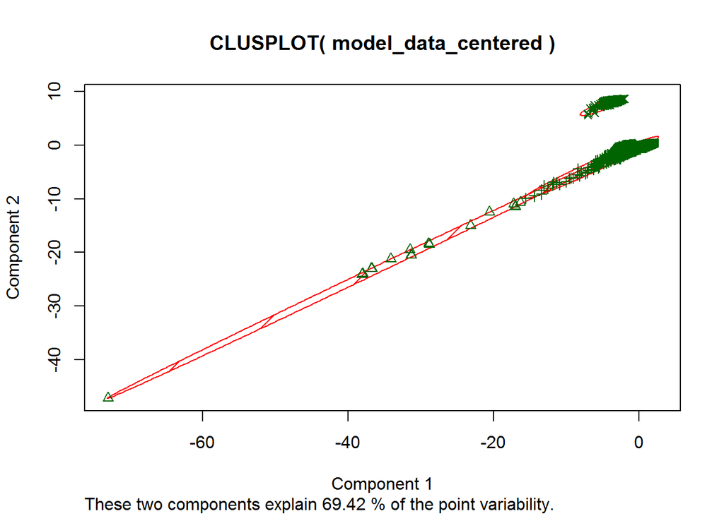

```r
# Generic function to plot cluster
clusplot(model_data_centered, o_kmean$cluster, color=TRUE, shade=TRUE,  lines=0)
```

- החישוב של `kmeans` יכול להשתנות מהרצה להרצה
- החבילה `pam` מחשבת `cluster` שהאשכולות יותר עמידים בין ההרצות

## עצי החלטה - Decision Trees

יש כמה ספריות שמריצים עצי החלטה.

אנחנו נדגים בעזרת הספרייה הבסיסית `rpart`

בנוסף לפורמולה אפשר לשחק עם הפרמטרים הספציפים.

כגון מדד החלטה לפי מה לפצל - פה בחרנו ב gini

פה הגדרנו ב `method` גם שהמשתנה הוא בינארי לעומת רציף או אורדינאלי

הסינטקס הבסיסי הוא:

> rpart(formula, data, method, paramters)

```r
library(rpart)

# 1. run the decision tree regression:
part_reg1 <- rpart( ind_cc ~ factor(last_3m_cc) + factor(last_6m_cc) + renta
                  ,data = model_train
                  , method = "class"
                  ,parms = list(prior = c(.98,.02), split = "gini"))

# 2. Show the outcomes
summary(part_reg1)
```

```
## Call:
## rpart(formula = ind_cc ~ factor(last_3m_cc) + factor(last_6m_cc) +
##     renta, data = model_train, method = "class", parms = list(prior = c(0.98,
##     0.02), split = "gini"))
##   n= 57875
##
##           CP nsplit rel error    xerror       xstd
## 1 0.02153478      0 1.0000000 1.0000000 0.03789736
## 2 0.01000000      3 0.9353957 0.9630882 0.03614006
##
## Variable importance
## factor(last_6m_cc) factor(last_3m_cc)
##                 54                 46
##
## Node number 1: 57875 observations,    complexity param=0.02153478
##   predicted class=0  expected loss=0.02  P(node) =1
##     class counts: 57187   688
##    probabilities: 0.980 0.020
##   left son=2 (55702 obs) right son=3 (2173 obs)
##   Primary splits:
##       factor(last_6m_cc) splits as  LRRRRRR,      improve=488.60530, (190 missing)
##       factor(last_3m_cc) splits as  LRRR,         improve=484.60000, (190 missing)
##       renta              < 100141.3 to the left,  improve=  3.43347, (0 missing)
##   Surrogate splits:
##       factor(last_3m_cc) splits as  LRRR, agree=0.99, adj=0.728, (0 split)
##
## Node number 2: 55702 observations
##   predicted class=0  expected loss=0.006227078  P(node) =0.9569982
##     class counts: 55497   205
##    probabilities: 0.994 0.006
##
## Node number 3: 2173 observations,    complexity param=0.02153478
##   predicted class=0  expected loss=0.326514  P(node) =0.04300183
##     class counts:  1690   483
##    probabilities: 0.673 0.327
##   left son=6 (1309 obs) right son=7 (864 obs)
##   Primary splits:
##       factor(last_3m_cc) splits as  LLRR,         improve=81.223990, (0 missing)
##       factor(last_6m_cc) splits as  -LLLRRR,      improve=66.527150, (0 missing)
##       renta              < 152532.7 to the left,  improve= 2.887691, (0 missing)
```

[output cut: 16 more lines]

```
##       factor(last_6m_cc) splits as  --LLLRR,      improve=14.485360, (0 missing)
##       renta              < 305221.4 to the left,  improve= 2.443772, (0 missing)
##   Surrogate splits:
##       factor(last_6m_cc) splits as  --LLLLR,      agree=0.823, adj=0.48, (0 split)
##       renta              < 478829.8 to the left,  agree=0.663, adj=0.01, (0 split)
##
## Node number 14: 570 observations
##   predicted class=0  expected loss=0.4045384  P(node) =0.01171303
##     class counts:   407   163
##    probabilities: 0.595 0.405
##
## Node number 15: 294 observations
##   predicted class=1  expected loss=0.4031859  P(node) =0.00667303
##     class counts:   157   137
##    probabilities: 0.403 0.597
```

```r
part_reg1
```

```
## n= 57875
##
## node), split, n, loss, yval, (yprob)
##       * denotes terminal node
##
##  1) root 57875 1157.5000 0 (0.980000000 0.020000000)
##    2) factor(last_6m_cc)=0 55702  344.8946 0 (0.993772922 0.006227078) *
##    3) factor(last_6m_cc)=1,2,3,4,5,6 2173  812.6054 0 (0.673486007 0.326513993)
##      6) factor(last_3m_cc)=0,1 1309  307.8815 0 (0.783887755 0.216112245) *
##      7) factor(last_3m_cc)=2,3 864  504.7238 0 (0.525677150 0.474322850)
##       14) factor(last_3m_cc)=2 570  274.2333 0 (0.595461601 0.404538399) *
##       15) factor(last_3m_cc)=3 294  155.7110 1 (0.403185916 0.596814084) *
```

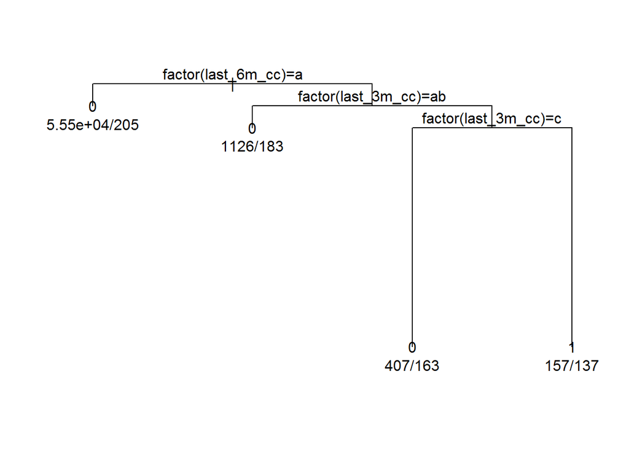

```r
# 3. Plot the tree
par(c(1,1), xpd = NA)
plot(part_reg1)
text(part_reg1, use.n = TRUE)
```

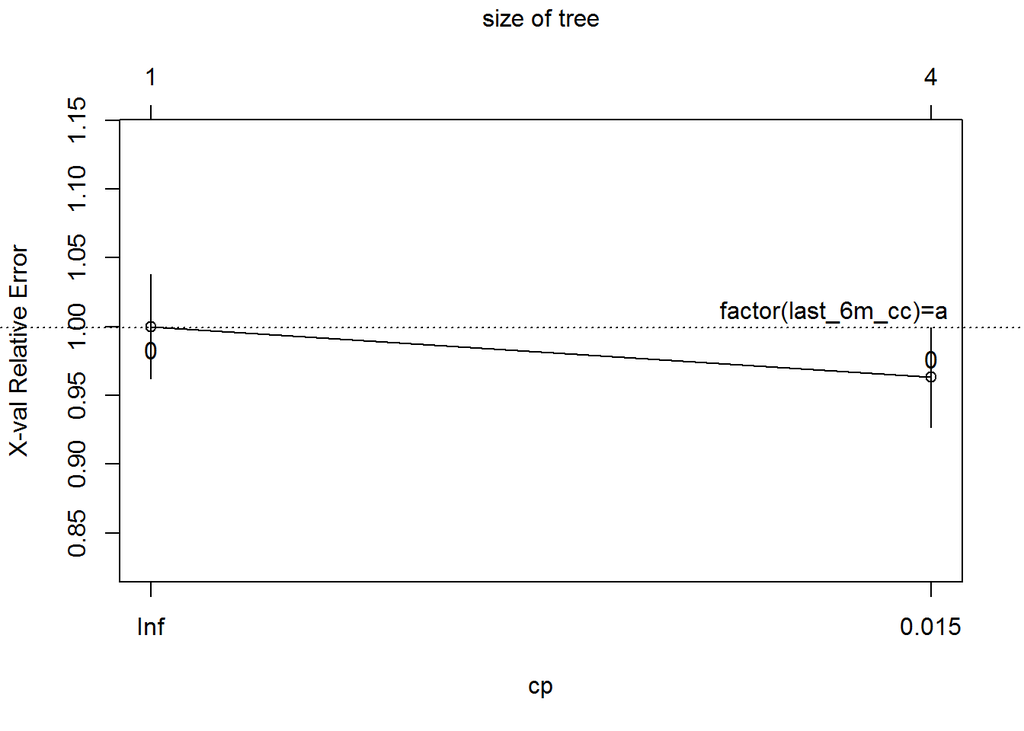

```r
# 4. Information plot:
plotcp(part_reg1)
text(part_reg1)
```

```r
# 5. Create predictions and check the Confusion matrix:
rpartPred <- predict(part_reg1, model_data, type = "class")
# requires 2 factor vectors
confusionMatrix(rpartPred, model_data$ind_cc)
```

```
## Confusion Matrix and Statistics
##
##           Reference
## Prediction     0     1
##          0 81468   784
##          1   232   194
##
##                Accuracy : 0.9877
##                  95% CI : (0.9869, 0.9885)
##     No Information Rate : 0.9882
##     P-Value [Acc > NIR] : 0.8917
##
##                   Kappa : 0.2711
##  Mcnemar's Test P-Value : <2e-16
##
##             Sensitivity : 0.9972
##             Specificity : 0.1984
##          Pos Pred Value : 0.9905
##          Neg Pred Value : 0.4554
##              Prevalence : 0.9882
##          Detection Rate : 0.9854
##    Detection Prevalence : 0.9948
##       Balanced Accuracy : 0.5978
##
##        'Positive' Class : 0
##
```

```r
###################################################3
# With CARET train I wasnt able to get a result...
# But I'll leave you the code to try out:
# cvCtrl <- trainControl(method = "repeatedcv",
#                        repeats = 3,
#                        summaryFunction = twoClassSummary,
#                        classProbs = TRUE)
#
# set.seed(1)
#
# rpartTune <- train(fml1
#                    ,data = model_test
#                    , method = "rpart"
#                    ,tuneLength = 30
#                    ,metric = "Accuracy"
#                    ,trControl = cvCtrl)
```

## טרנספרומציה בעזרת Principal Components Analysis

ניתן להשתמש ב PCA כשיטה להקטנת מימדיות או למשל כשיש הרבה משתנים דומים …

אנחנו נשתמש באחד הפקודות של `CARET` לביצוע PCA כהכנה לשלב מידול הבא

נעשה זאת בעזרת הפקודה `PreProcess`

```r
# choose only coloumns starting with `l6m`
small_data <- model_data %>% select(starts_with("l6m"))

# with CARET - preProcess
trans <-  preProcess(small_data,
                     method=c("BoxCox", "center", "scale", "pca"))

PC <-  predict(trans, small_data)
summary(PC)
```

```
##       PC1               PC2                PC3
##  Min.   :-9.6954   Min.   :-10.8204   Min.   :-10.6290
##  1st Qu.: 0.1722   1st Qu.: -0.5114   1st Qu.: -0.3887
##  Median : 0.6315   Median :  0.3701   Median :  0.3370
##  Mean   : 0.0000   Mean   :  0.0000   Mean   :  0.0000
##  3rd Qu.: 1.0985   3rd Qu.:  0.5851   3rd Qu.:  0.4099
##  Max.   : 1.4682   Max.   :  3.7232   Max.   :  7.9477
##  NA's   :263       NA's   :263        NA's   :263
##       PC4                PC5                PC6
##  Min.   :-13.8366   Min.   :-21.5784   Min.   :-33.60513
##  1st Qu.: -0.3009   1st Qu.: -0.1273   1st Qu.:  0.03613
##  Median :  0.2332   Median :  0.1169   Median :  0.15040
##  Mean   :  0.0000   Mean   :  0.0000   Mean   :  0.00000
##  3rd Qu.:  0.2907   3rd Qu.:  0.2929   3rd Qu.:  0.29484
##  Max.   :  9.7139   Max.   :  7.0058   Max.   :  2.54533
##  NA's   :263        NA's   :263        NA's   :263
##       PC7                PC8                 PC9
##  Min.   :-26.0388   Min.   :-61.67077   Min.   :-217.65114
##  1st Qu.: -0.3244   1st Qu.: -0.09203   1st Qu.:  -0.00005
##  Median : -0.1025   Median : -0.06585   Median :   0.00031
##  Mean   :  0.0000   Mean   :  0.00000   Mean   :   0.00000
##  3rd Qu.:  0.2080   3rd Qu.: -0.02108   3rd Qu.:   0.05207
##  Max.   : 31.9290   Max.   : 68.30237   Max.   :   7.50764
##  NA's   :263        NA's   :263         NA's   :263
##       PC10                PC11               PC12
##  Min.   :-26.34059   Min.   :-5.75199   Min.   :-21.76098
##  1st Qu.: -0.11193   1st Qu.:-0.04743   1st Qu.: -0.08614
##  Median :  0.08484   Median : 0.08144   Median : -0.06919
##  Mean   :  0.00000   Mean   : 0.00000   Mean   :  0.00000
##  3rd Qu.:  0.13699   3rd Qu.: 0.09398   3rd Qu.:  0.12498
##  Max.   : 83.65843   Max.   :60.16775   Max.   : 20.53030
##  NA's   :263         NA's   :263        NA's   :263
##       PC13                PC14                PC15
##  Min.   :-14.66844   Min.   :-37.13095   Min.   :-13.8914
##  1st Qu.: -0.07799   1st Qu.:  0.00593   1st Qu.: -0.2269
##  Median :  0.10240   Median :  0.03172   Median :  0.1578
##  Mean   :  0.00000   Mean   :  0.00000   Mean   :  0.0000
##  3rd Qu.:  0.13063   3rd Qu.:  0.04764   3rd Qu.:  0.1841
##  Max.   : 15.09130   Max.   :  7.54347   Max.   : 24.8700
##  NA's   :263         NA's   :263         NA's   :263
##       PC16               PC17               PC18
##  Min.   :-7.47574   Min.   :-10.0090   Min.   :-5.59104
##  1st Qu.:-0.16543   1st Qu.: -0.3184   1st Qu.:-0.31505
##  Median : 0.05723   Median : -0.2348   Median : 0.08597
##  Mean   : 0.00000   Mean   :  0.0000   Mean   : 0.00000
##  3rd Qu.: 0.23509   3rd Qu.:  0.4395   3rd Qu.: 0.14893
##  Max.   :10.39700   Max.   : 18.0026   Max.   : 7.55454
##  NA's   :263        NA's   :263        NA's   :263
##       PC19              PC20
##  Min.   :-4.6132   Min.   :-3.93936
##  1st Qu.:-0.3201   1st Qu.:-0.23212
##  Median :-0.2454   Median : 0.00295
##  Mean   : 0.0000   Mean   : 0.00000
##  3rd Qu.: 0.4416   3rd Qu.: 0.45422
##  Max.   : 4.3491   Max.   : 3.70967
##  NA's   :263       NA's   :263
```

# חבילות מומלצות

מה שהוצג במערך הזה הוא רק בגדר ספתח ל ML ב R

מי שרוצה להיכנס לנושא לעומק צריך ללכלך את הידיים ולהבין את הפרמטרים של כל

פקודה ושיטה.

מספר חבילות מומלצות ל ML ב R:

- CARET - להבין את מגוון האפשרויות שלה - כעקרון יש פקודה בסיסית של `train` שעליה מזינים את השיטה שרוצים להריץ ואת הפרמטרים הרלוונטיים.

**דרוש ניסיון והתנסות בשביל לשלוט ולהתאים כל שיטה…**

- H20 - אחד החבילות המובילות בתחום ה ML - החבילה מייצרת מחשב ורטואלי בתוך ה R ובעצם מפעילה את האלגורתמים בחישובים מקבילים כש R זה רק מעטפת
- randomForest - יערות החלטה
- XGBOOST - חישוב של יערות החלטה מוגבר… בערך
- nnet ו neuralnet - ספריות לחישוב neural network המדמה את הרצפטורים של המוח - כביכול…

ועוד …….